# C42B cells treatment comparison

# Venn diagram on steroids (UpsetPlot)

Conditions we want to compare:

- Treatment_Abi_5_vs_DMSO
- Treatment_Enz_20_vs_DMSO
- Treatment_Ola_1_vs_DMSO
- Treatment_Tala_10_vs_DMSO
- Treatment_Abi_Ola_vs_DMSO
- Treatment_Enz_Tala_vs_DMSO
- Treatment_Ola_1_vs_Abi_Ola
- Treatment_Abi_5_vs_Abi_Ola
- Treatment_Enz_20_vs_Enz_Tala
- Treatment_Ola_1_vs_Enz_Tala

I extracted all significantly differentially expressed genes (DEGs) for each condition (|log2Fc| >= 1 and pval < 0.05).

**Set size** = how many DEGs there are per sample

**Intersection size** = How many genes are shared between the x samples tied together with the bar + nodes

So if you sum up all the intersection size with a dot in a sample, you get the set size of that sample. It’s essentially a venn diagram for when you have >3 samples you want to compare.

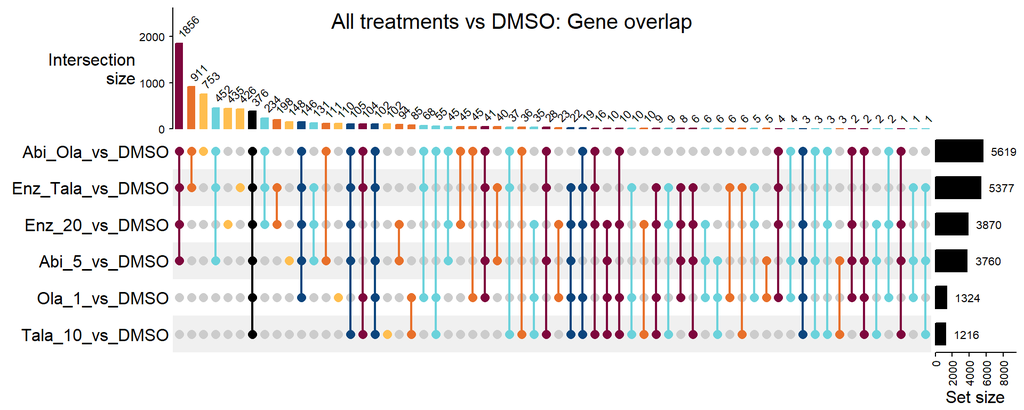

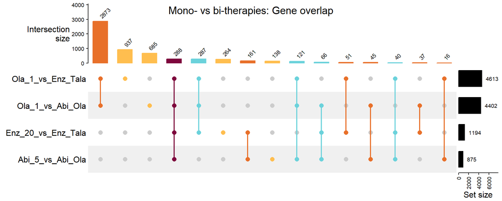